# HW 02

Author

Nathan Herling

Published

June 13, 2025

## 0 - Setup

```
[FYI]
'pacman' already installed — skipping install.
```

```
[FYI]
'dsbox' already installed — skipping GitHub install.
```

```
The packages loaded:
```

```
* tidyverse           * glue                * scales              * lubridate
* patchwork           * ggh4x               * ggrepel             * openintro
* ggridges            * dsbox               * janitor             * here
* knitr               * ggthemes            * ggplot2             * kableExtra
```

## 1 - A new day, a new plot, a new geom

> **Question #1**

> A new day, a new plot, a new geom. The goal of this exercise is to learn about a new type of plot (ridgeline plot) and to learn how to make it. Use the `geom_density_ridges()` function from the `ggridges` package to make a ridge plot of Airbnb review scores of Edinburgh neighborhoods. The neighborhoods should be ordered by their median review scores. The data can be found in the `dsbox` package, and it’s called `edibnb`. Also include an interpretation for your visualization. You should review feedback from your Homework 1 to make sure you capture anything you may have missed previously.

Table 1. Diagnostic Summary for `review_scores_rating` (edibnb data set)

| Metric | Value |
| --- | --- |
| Data Type | numeric |
| Min | 20 |
| 1st Quartile | 93 |
| Median | 97 |
| Mean | 95.0246657029274 |
| 3rd Quartile | 99 |
| Max | 100 |
| Missing Values | 2177 |
| IQR | 6 |
| Lower Outlier Bound | 84 |
| Upper Outlier Bound | 108 |
| Outlier Count | 576 |

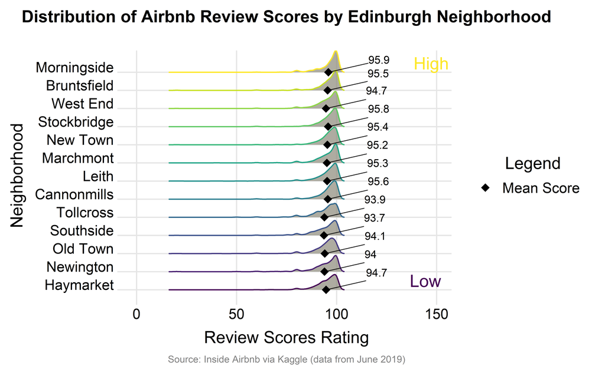

## 2 - Foreign Connected PACs

**Question #2**

[figure not shown]

## 3 - Median housing prices in the US

**Question #3**

## 4 - Expect More. Plot More.

**Question #4**

**Recreate the Target LOGO**

[figure not shown]

## 5 - Mirror, mirror on the wall, who’s the ugliest of them all?

**Question #5**